# Reviewing & debugging code

Lesley Duff

2023-11-05

# Reviewing & debugging code

```r
library(tidyverse)
energy_scotland <- read_csv("data/energy_scotland.csv")
energy_scotland
```

| year | sector | energy_prod |
| --- | --- | --- |
| 2006 | Gas | 10212.40 |
| 2010 | Renewables | 9501.36 |
| 2012 | Oil | 639.06 |
| 2013 | Renewables | 16989.60 |
| 2008 | Gas | 11607.86 |
| 2008 | Renewables | 9058.47 |
| 2010 | Gas | 8380.64 |
| 2016 | Coal | 2263.19 |
| 2012 | Gas | 5612.60 |
| 2011 | Pumped hydro | 604.21 |

[output cut: 68 more lines]

```r
all_salaries <- read_csv("data/all_salaries.csv")
all_salaries
```

| gender | name | surname | job_area | salary | age | retired | location | savings |
| --- | --- | --- | --- | --- | --- | --- | --- | --- |
| Female | Florence | Johnson | Human Resources | 22000 | 46 | No | Shetland | 31394 |
| Male | Freddy | Johnson | Training | 23000 | 59 | No | Western Isles | 27730 |
| Male | Freddy | Williamson | Human Resources | 16000 | 70 | Yes | Edinburgh | 41067 |
| Male | Bert | Jamieson | Sales | 16000 | 64 | No | Glasgow | 42729 |
| Female | Florence | Thomason | Human Resources | 21000 | 42 | No | Aberdeen | 39691 |
| Male | Charles | Williamson | Sales | 20000 | 77 | Yes | Glasgow | 28519 |
| Female | Emmy | Galdie | Sales | 20000 | 72 | Yes | Western Isles | 21672 |
| Female | Gilly | Smith | Training | 16000 | 32 | No | Aberdeen | 37760 |
| Male | Freddy | Manson | Training | 27000 | 74 | Yes | Stirling | 33052 |
| Male | Gord | Peterson | Human Resources | 16000 | 43 | No | Edinburgh | 33664 |

[output cut: 990 more lines]

## Task 1

Goal: return the row in the data which has the maximum energy production, making sure the code would work if new data was added to the dataset.

### Old code

```r
max(energy_scotland$energy_prod)
```

```
## [1] 25165.9
```

```r
# this returns value 25165.9

energy_scotland %>%
  filter(energy_prod == 25165.9)
```

| year | sector | energy_prod |
| --- | --- | --- |
| 2017 | Renewables | 25165.9 |

This code displays the required row but does not store the result so it can be reused programmatically.

### New code

```r
# The brief does not described expected behaviour if more than one row has the
# same maximum value of energy_prod. We are assuming in this context that
# multiple rows should be returned if there are equal values for maximum
# detected so no important data is discarded.
row_maximum_energy_production <- energy_scotland %>%
  # N.B. Assumption is multiple rows with equal max energy_prod desired.
  # If this is not the case add with_ties = FALSE to the slice_max call in
  # the next line
  slice_max(energy_prod, n = 1)

# Return the row(s) with the maximum energy_prod
row_maximum_energy_production
```

| year | sector | energy_prod |
| --- | --- | --- |
| 2017 | Renewables | 25165.9 |

In the old code the value obtained from max was manually hard-coded to one value. The filter line did not automatically use this maximum value. Both lines replaced by a single more efficient line using slice_max which will always recalculate the maximum value for energy_prod.

The following code chunk shows testing of the previous new code

```r
# The following is a test to ensure the same line of code works if new data was
# added to the dataset test_energy_scotland will be created as a copy but with
# a new row added with dummy test data including a new max energy_prod of twice
# the previous maximum
test_energy_scotland <- energy_scotland %>%
  # Dummy test data with a new higher maximum energy_prod
    add_row(
    tibble_row(
      year = 2024,
      sector = "Renewables",
      energy_prod = row_maximum_energy_production$energy_prod * 2
    )
    )

test_row_maximum_energy_production <- test_energy_scotland %>%
  slice_max(energy_prod, n = 1)

# Check our new dummy max highest is present TRUE = Yes
test_row_maximum_energy_production$energy_prod ==
  (row_maximum_energy_production$energy_prod * 2)
```

```
## [1] TRUE
```

```r
# Clean up test data
rm(test_row_maximum_energy_production, test_energy_scotland)
```

## Task 2

Goal: create a new column called ‘rating’ to the energy table which will take the following values in the table. The bins should be inclusive of the upper value e.g. is the energy production is 20,000 exactly then will be ‘high’, if it’s 10,000 exactly then will be ‘medium’, etc.

| lower energy production | upper energy production | rating |
| --- | --- | --- |
| 20000 |  | very high |
| 10000 | 20000 | high |
| 5000 | 10000 | medium |
| 2000 | 5000 | low |
|  | 2000 | very low |

### Old code

```r
rating <- if_else(energy_scotland$energy_prod > 20000, "very high", if_else(energy_scotland$energy_prod > 10000 & energy_scotland$energy_prod <= 20000, "high", if_else(energy_scotland$energy_prod > 5000 & energy_scotland$energy_prod <= 10000, "medium", if_else(energy_scotland$energy_prod > 2000 & energy_scotland$energy_prod <= 5000, "low", "very low"))))

energy_scotland_rating <- bind_cols(energy_scotland, rating = rating)
```

The following chunk is testing whether the above is as expected

```r
# Testing old code test data test_energy_scotland replacing energy_scotland
# Test outside ranges and on each range boundary.
test_energy_scotland <- tibble(
  energy_prod = c(30000,
                  20000,
                  15000,
                  10000,
                   5000,
                  2000,
                  1000)
)

test_rating <- if_else(test_energy_scotland$energy_prod > 20000, "very high", if_else(test_energy_scotland$energy_prod > 10000 & test_energy_scotland$energy_prod <= 20000, "high", if_else(test_energy_scotland$energy_prod > 5000 & test_energy_scotland$energy_prod <= 10000, "medium", if_else(test_energy_scotland$energy_prod > 2000 & test_energy_scotland$energy_prod <= 5000, "low", "very low"))))

test_energy_scotland_rating <- bind_cols(test_energy_scotland, rating = test_rating)
test_energy_scotland_rating
```

| energy_prod | rating |
| --- | --- |
| 30000 | very high |
| 20000 | high |
| 15000 | high |
| 10000 | medium |
| 5000 | low |
| 2000 | very low |
| 1000 | very low |

```r
rm(test_energy_scotland_rating, test_energy_scotland, test_rating) # remove test data
```

Old code appears to work correctly but is difficult to read and will be more awkward to change if new ratings are required.

### New code

```r
energy_scotland_rating <- energy_scotland %>%
  mutate(
    rating = case_when(
      energy_prod > 20000 ~ "very high",
      energy_prod > 10000  & energy_prod <= 20000 ~ "high",
      energy_prod > 10000  & energy_prod <= 20000 ~ "high",
      energy_prod > 5000  & energy_prod <= 10000 ~ "medium",
      energy_prod > 2000  & energy_prod <= 5000 ~ "low",
      energy_prod <= 2000 ~ "very low"
    )
  )
```

The old code created a vector of ratings then used `bind_cols` to combine this with the existing dataframe. This code appears to work correctly but is a bit hard to read. Using bind_cols also assumes that the two dataframes are in the *exact* same order. This appears to work in this instance but could be more brittle in the future if new code that changes order is inserted before the `bind_cols` call.

Instead I’ve used `dplyr::mutate` to directly create a new column in the dataframe to avoid having to bind or join. This code should be easier to read, maintain and extend as the logical conditions determining the ranking bins are clearer.

## Task 3

Goal: create a plot which shows how the energy production for the sectors renewables, gas and pumped hydro compare over time.

### Old code

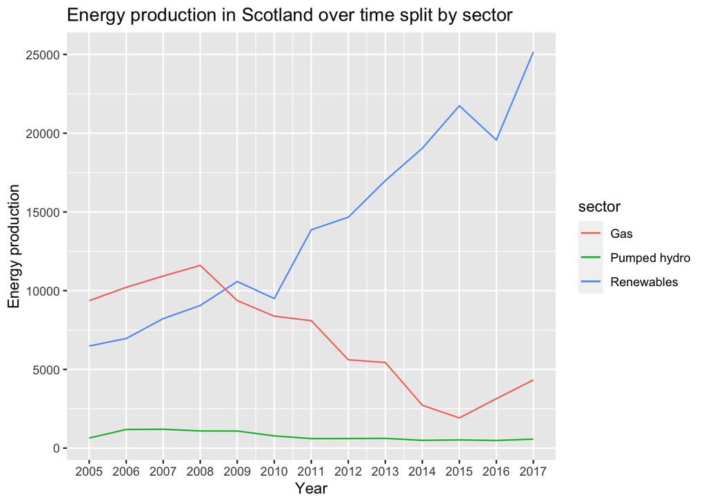

```r
renewable <- energy_scotland %>%
  filter(sector == "Renewables")

gas <- energy_scotland %>%
  filter(sector == "Gas")

hydro <- energy_scotland %>%
  filter(sector == "Pumped hydro")

years <- unique(energy_scotland$year)

ggplot() +
  geom_line(aes(x = year, y = energy_prod,  color = sector), data = renewable) +
  geom_line(aes(x = year, y = energy_prod, color = sector), data = gas) +
  geom_line(aes(x = year, y = energy_prod, color = sector), data = hydro) +
  scale_x_continuous(breaks = years) +
  labs(title = "Energy production in Scotland over time split by sector",
       x ="Year", y = "Energy production")
```

This code works but some code not so flexible and the plot could have some visual changes to make the values/differences between sectors clearer.

### New code

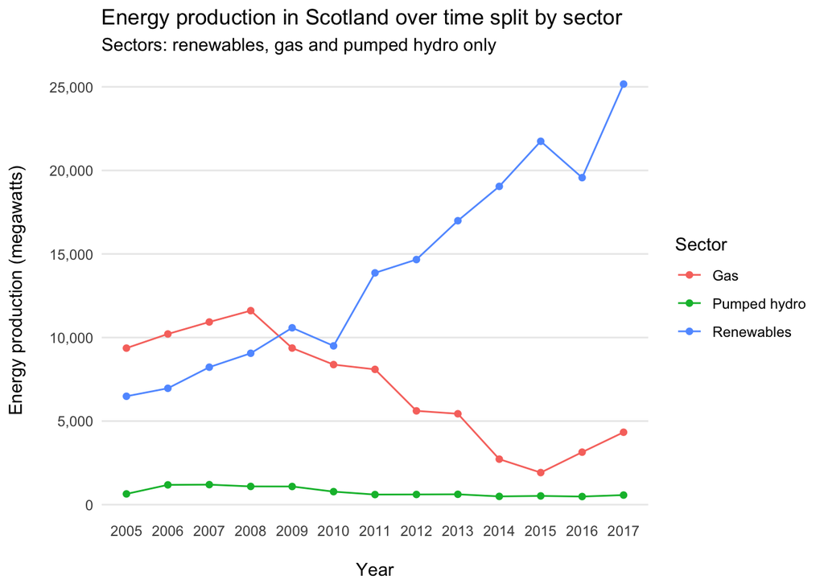

```r
compare_sectors <- c("Renewables", "Gas", "Pumped hydro")
# Which sectors are we interested in comparing?

energy_scotland %>%
  filter(sector %in% compare_sectors) %>%
  ggplot(aes(x = year, y = energy_prod, colour = sector)) +
  geom_line() +
  geom_point() + # Make sure we add actual observation values
  scale_y_continuous(labels = scales::comma) +
  scale_x_continuous(breaks = scales::breaks_width(1)) + # Break by 1 year
  theme_minimal() +
  # Lighter theme and remove less important grid lines
  theme(
    panel.grid.minor.y = element_blank(),
    panel.grid.major.x = element_blank(),
    panel.grid.minor.x = element_blank()
  ) +
  labs(
    title = "Energy production in Scotland over time split by sector",
    subtitle = "Sectors: renewables, gas and pumped hydro only",
    x = "\nYear",
    y = "Energy production (megawatts)\n",
    colour = "Sector"
  )
```

```r
rm(compare_sectors)
```

- Added subtitle to make it clearer that the sectors on the plot are only a subset rather than all sectors.
- Added megawatts as units to y axis
- Add points for the actual observations each year.
- Applied a lighter theme
- Formatted large numbers with commas.
- Scaled x by 1 year intervals. Removed minor breaks.
- Removed some grid lines to increase clarity and put more emphasis on sector lines.
- Added whitespace to labels

## Task 4

Goal: calculate the average energy production for the Coal, Gas, and Oil sectors across the time period in the data.

### Old code

```r
energy_scotland %>%
  filter(sector == c("Coal", "Gas", "Oil")) %>%
  group_by(sector) %>%
  summarise(avg_energy_prod = mean(energy_prod))
```

| sector | avg_energy_prod |
| --- | --- |
| Coal | 11563.698 |
| Gas | 8339.125 |
| Oil | 1057.718 |

I believe the original code is producing incorrect values. Line `sector == c("Coal", "Gas", "Oil")` is checking if sector is equal to *all* elements of vector c(“Coal”, “Gas”, “Oil”) rather than checking if sector matches *any* element.

### New Code:

```r
energy_scotland %>%
  filter(sector %in% c("Coal", "Gas", "Oil")) %>%
  group_by(sector) %>%
  summarise(avg_energy_prod = mean(energy_prod))
```

| sector | avg_energy_prod |
| --- | --- |
| Coal | 10444.602 |
| Gas | 7010.062 |
| Oil | 1154.682 |

I am assuming the intention of this task is for separate average values for each of the Coal/Gas/Oil sectors individually rather than an average of Coal/Gas/Oil combined.

## Task 5

```r
student <- tibble(
  Name = c("Brian", "David", "Karen"),
  age = c(25, 56, 40),
  location = c("Scotland", "England", "scotland"),
  `email address` = c("briang@yahoo.co.uk", "dsmith@gmail.co.uk", "karen")
)

student
```

| Name | age | location | email address |
| --- | --- | --- | --- |
| Brian | 25 | Scotland | briang@yahoo.co.uk |
| David | 56 | England | dsmith@gmail.co.uk |
| Karen | 40 | scotland | karen |

Goal: clean up this tibble by only returning the name, location and email address information, putting the location information into lowercase and also creating a new column called valid_email to have values TRUE or FALSE whether the email address is valid. Here our definition is valid is that it contains an @ symbol followed by a combination of lowercase characters or a . symbol.

### Old code

```r
student %>%
  select(name, location, email_address) %>%
  janitor::clean_names() %>%
  str_to_lower(location)
  mutate(valid_email = str_detect(email_address, "@a-z.")
```

### New code

```r
student %>%
  janitor::clean_names() %>%
  select(name, location, email_address) %>%
  mutate(location = str_to_lower(location),
    valid_email = str_detect(email_address, "@[a-z\\.]+"))
```

| name | location | email_address | valid_email |
| --- | --- | --- | --- |
| Brian | scotland | briang@yahoo.co.uk | TRUE |
| David | england | dsmith@gmail.co.uk | TRUE |
| Karen | scotland | karen | FALSE |

Old code does not work - here’s the problems the code has been changed for

1. missing pipe on end of str_to_lower line.
2. Missing closing bracket on mutate line
3. select line does not work due to order of call of `janitor::clean_names()`
4. str_to_lower needs to go inside a mutate to store the change
5. valid_email check wasn’t matching the character class for a-z. It was also matching *any* character after ‘z’ rather than literally the ‘.’ character.

## Task 6

### Old code

```r
subsetting_salaries <- function(dataframe_input,job_area_input,salary_input){
  data <- dataframe_input %>% select(job_area) %>% filter(job_area == job_area_input)
  data1 <- data[data$savings > salary_input, ]
}

subsetting_salaries(CodeClanData::all_salaries, Human Resources, 30000)
```

### New code

```r
# The function should only return the employees in the dataframe that have a salary above this value salary_input and who work in job area job_area_input
subsetting_salaries <- function(dataframe_input, job_area_input, salary_input) {
  data <- dataframe_input %>%
    filter((job_area == job_area_input) &
             (salary > salary_input))

  # Good practice to use an explicit return
  return(data)
}

subsetting_salaries(all_salaries, "Legal", 30000)
```

| gender | name | surname | job_area | salary | age | retired | location | savings |
| --- | --- | --- | --- | --- | --- | --- | --- | --- |
| Female | Helena | Johnson | Legal | 31000 | 76 | Yes | Aberdeen | 30924 |
| Female | Helena | Jamieson | Legal | 36000 | 27 | No | Western Isles | 50211 |
| Female | Dora | Robertson | Legal | 31000 | 88 | Yes | Orkney | 27883 |

```r
# Test of same job_area but lower salary = more results
subsetting_salaries(all_salaries, "Legal", 20000)
```

| gender | name | surname | job_area | salary | age | retired | location | savings |
| --- | --- | --- | --- | --- | --- | --- | --- | --- |
| Male | Harry | Thomason | Legal | 22000 | 58 | No | Glasgow | 45438 |
| Male | Freddy | Laurenceso | Legal | 22000 | 79 | Yes | Edinburgh | 26687 |
| Female | Gilly | Manson | Legal | 26000 | 50 | No | Shetland | 38461 |
| Female | Gilly | Halcrow | Legal | 24000 | 77 | Yes | Orkney | 20830 |
| Female | Dora | Mowat | Legal | 21000 | 58 | No | Aberdeen | 17137 |
| Female | India | Irvine | Legal | 26000 | 88 | Yes | Western Isles | 20667 |
| Male | Angus | Irvine | Legal | 21000 | 71 | Yes | Shetland | 42958 |
| Male | Freddy | Jamieson | Legal | 26000 | 40 | No | Aberdeen | 39933 |
| Female | Florence | Johnson | Legal | 21000 | 67 | Yes | Orkney | 25003 |
| Male | Harry | Sinclair | Legal | 25000 | 50 | No | Glasgow | 25657 |

[output cut: 77 more lines]

```r
# Another test to check getting different results for other job area for
# for original salary
subsetting_salaries(all_salaries, "Human Resources", 30000)
```

| gender | name | surname | job_area | salary | age | retired | location | savings |
| --- | --- | --- | --- | --- | --- | --- | --- | --- |
| Male | Angus | Halcrow | Human Resources | 33000 | 54 | No | Orkney | 44806 |

Old code problems and their solutions:

1. job_area_input in function call not in quotes
2. old code testing against ‘savings’ not ‘salary’ as requested
3. Don’t require the ‘select’ line
4. don’t require to create second data1 frame as filter can generate dataframe
5. Add an explicit return of the modified dataframe for clarity
6. Readability improvements - small formatting changes and whitespace have been added

```r
# Clean up environment
rm(all_salaries)
rm(energy_scotland, energy_scotland_rating)
rm(gas, hydro, renewable)
rm(rating, row_maximum_energy_production, years)
rm(student)
```